# Reproducible Research Week 2 Project

Po Hsuan Ho

11/22/2020

```r
setwd("C:/Users/PO HSUAN/Downloads")
if (!file.exists("activity.csv") )
    {
     dlurl <- 'http://d396qusza40orc.cloudfront.net/repdata%2Fdata%2Factivity.zip'
     download.file(dlurl,destfile='repdata%2Fdata%2Factivity.zip',mode='wb')
     unzip('repdata%2Fdata%2Factivity.zip')
    }
Activity<-read.csv("activity.csv")
head(Activity)
```

```
##   steps       date interval
## 1    NA 2012-10-01        0
## 2    NA 2012-10-01        5
## 3    NA 2012-10-01       10
## 4    NA 2012-10-01       15
## 5    NA 2012-10-01       20
## 6    NA 2012-10-01       25
```

Calculate the total number of steps taken per day Make a histogram of the total number of steps taken each day Calculate and report the mean and median of the total number of steps taken per day: mean=10766.19 median=10765

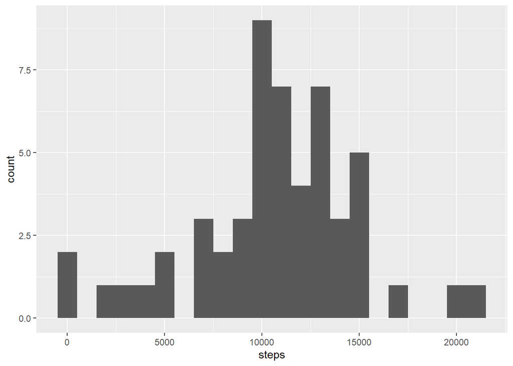

```r
r = getOption("repos")
r["CRAN"] = "http://cran.us.r-project.org"
options(repos = r)
install.packages("ggplot2")
library(ggplot2)
stepPerDay<-aggregate(steps~date,Activity,sum)
g<-ggplot(stepPerDay, aes(steps))
g+geom_histogram(binwidth = 1000)
```

```r
mean(stepPerDay$steps)
```

```
## [1] 10766.19
```

```r
median(stepPerDay$steps)
```

```
## [1] 10765
```

Make a time series plot of the 5-minute interval (x-axis) and the average number of steps taken, averaged across all days (y-axis) Which 5-minute interval, on average across all the days in the dataset, contains the maximum number of steps? 835

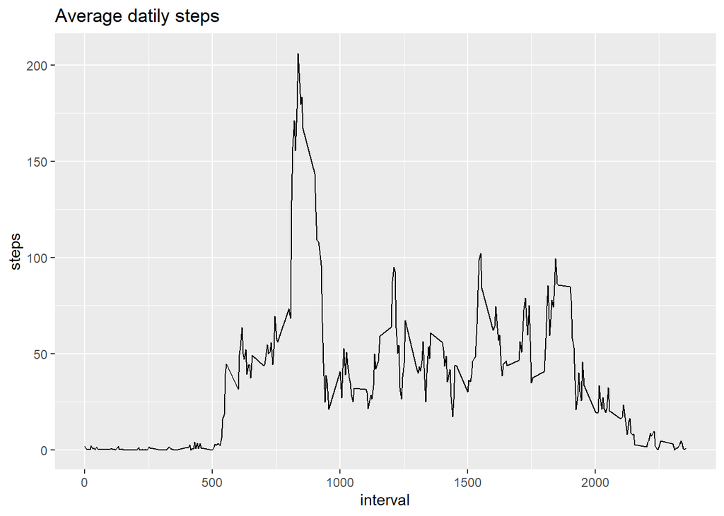

```r
stepPer5Min<-aggregate(steps~interval,Activity, mean)
g2<-ggplot(stepPer5Min,aes(interval, steps))+geom_line()+labs(title="Average datily steps")
g2
```

```r
stepPer5Min[stepPer5Min$steps==max(stepPer5Min$steps),]
```

```
##     interval    steps
## 104      835 206.1698
```

Calculate and report the total number of missing values in the dataset: 2304 Devise a strategy for filling in all of the missing values in the dataset. For example, you could use the mean/median for that day, or the mean for that 5-minute interval, etc.

Create a new dataset that is equal to the original dataset but with the missing data filled in.

```r
sum(is.na(Activity))
```

```
## [1] 2304
```

```r
noMissing<-Activity
for(i in stepPer5Min$interval){
  noMissing[noMissing$interval==i & is.na(noMissing$steps),]$steps<-stepPer5Min$steps[stepPer5Min$interval==i]}
head(noMissing)
```

```
##       steps       date interval
## 1 1.7169811 2012-10-01        0
## 2 0.3396226 2012-10-01        5
## 3 0.1320755 2012-10-01       10
## 4 0.1509434 2012-10-01       15
## 5 0.0754717 2012-10-01       20
## 6 2.0943396 2012-10-01       25
```

```r
sum(is.na(noMissing))
```

```
## [1] 0
```

Make a histogram of the total number of steps taken each day and Calculate and report the mean and median total number of steps taken per day. Do these values differ from the estimates from the first part of the assignment? What is the impact of imputing missing data on the estimates of the total daily number of steps? The mean is the same but the median shifted by one after filling up the missing values.

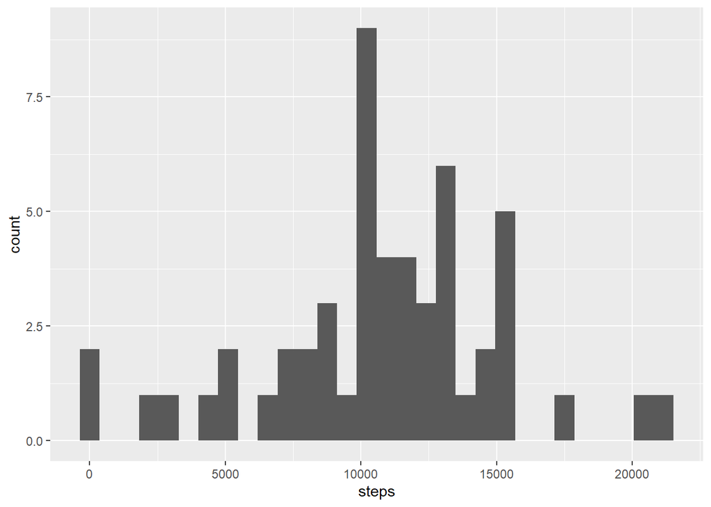

```r
totalSteps<-aggregate(steps~date, data=Activity, sum)
totalStepsNoMissing<-aggregate(steps~date, data=noMissing, sum)
g3<-ggplot(aes(steps), data=totalSteps)+geom_histogram()
g4<-ggplot(aes(steps), data=totalStepsNoMissing)+ geom_histogram()
g3
```

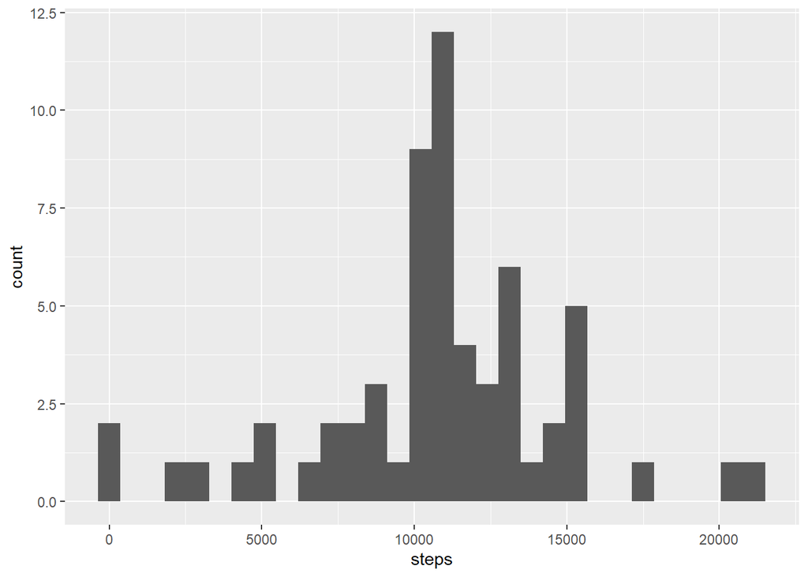

```r
g4
```

```r
summary(totalSteps)
```

```
##          date        steps
##  2012-10-02: 1   Min.   :   41
##  2012-10-03: 1   1st Qu.: 8841
##  2012-10-04: 1   Median :10765
##  2012-10-05: 1   Mean   :10766
##  2012-10-06: 1   3rd Qu.:13294
##  2012-10-07: 1   Max.   :21194
##  (Other)   :47
```

```r
summary(totalStepsNoMissing)
```

```
##          date        steps
##  2012-10-01: 1   Min.   :   41
##  2012-10-02: 1   1st Qu.: 9819
##  2012-10-03: 1   Median :10766
##  2012-10-04: 1   Mean   :10766
##  2012-10-05: 1   3rd Qu.:12811
##  2012-10-06: 1   Max.   :21194
##  (Other)   :55
```

Create a new factor variable in the dataset with two levels – “weekday” and “weekend” indicating whether a given date is a weekday or weekend day.

```r
noMissing$date<-as.Date(noMissing$date)
noMissing$day<-weekdays(noMissing$date)
noMissing$week<-ifelse(noMissing$day=="Saturday"|noMissing$day=="Sunday","weekend", "weekday")
```

Make a panel plot containing a time series plot of the 5-minute interval (x-axis) and the average number of steps taken, averaged across all weekday days or weekend days (y-axis). See the README file in the GitHub repository to see an example of what this plot should look like using simulated data.

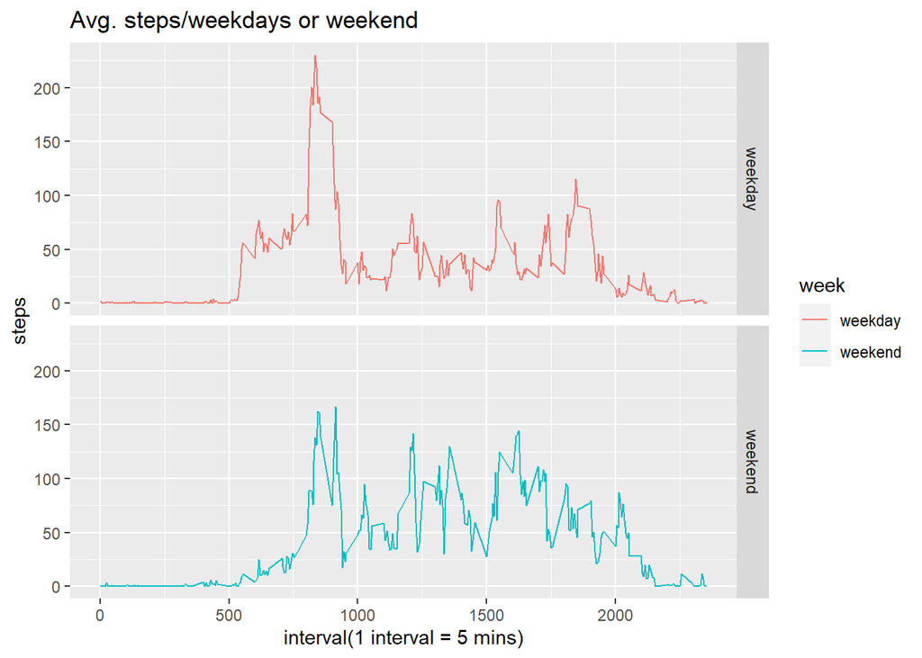

```r
avgStepWeek<-aggregate(steps~interval+week,noMissing,mean)
g5<-ggplot(data=avgStepWeek, aes(colour=week, x=interval, y=steps))+geom_line()+labs(x="interval(1 interval = 5 mins)", y="steps", title="Avg. steps/weekdays or weekend")+facet_grid(week~.)
g5
```